# How the World is Stopping Sexual Harassment in Film

Nichole Yao, Yuqing Geng, Rowan Wheeler

Dec 14th, 2017

Get the data on [GitHub](https://github.com/rowanwheeler/finalimdbproject.git)

[figure not shown]

Director Patty Jenkins and lead actor Gal Gadot on the set of $800m blockbuster Wonder Woman. Photograph: Clay Enos.

Almost daily, another prominent man in Hollywood is accused of sexual harassment. As the voices of powerful female actors, directors, producers, and other film industry figures have spoken out against sexual harassment, The #MeToo movement [^1] in the United States has had a profound impact. It has held many powerful men accountable for their inappropriate conduct. It has even been [named the 2017 Times Magazine Person of the Year](http://time.com/time-person-of-the-year-2017-silence-breakers/). However, the impact of this movement has spread beyond the United States. As it struggles to change its toxic environment, Hollywood must look globally to determine what other actions it can take to prevent harassment in the future.

As the amount of women working in the global film industry grows, women’s voices increase in power, both onscreen and off [^2]. To create more opportunities for women in film, Hollywood must look internationally to learn from actions taken by other countries. To gain insight into the history of women in Hollywood, we examined how the percentage of women in positions of power in Hollywood has changed over time and how that percentage compares to international percentages of female filmmakers. We wanted to know if the United States has higher levels of female producers and directors than other countries and how other countries responded to the #MeToo movement.

## Women in Hollywood

[A 2015 report from researchers at Kent State University](https://www.researchgate.net/publication/283244891_Sexual_Harassment_A_Complex_Adaptive_System_Viewpoint) and the University of Texas at Tyler found that the “prevalence of male norms in the male-dominated environment may result in a more hostile workplace for women who are perceived by men as violators of the gender norms.” The overwhelming power held by male producers and directors within Hollywood creates a breeding ground for sexual harassment.

Harassment also occurs when people are seen as disposable. Companies pay millions of dollars in settlements to protect their star performers, as [Fox did with Bill O’Reilly](https://www.washingtonpost.com/lifestyle/style/bill-oreilly-settled-sixth-sexual-harassment-claim-for-32-million/2017/10/21/ff34b24c-b68c-11e7-9e58-e6288544af98_story.html?utm_term=.d7c83589994f). In Hollywood, where knowing the right people can help you gain or lose a job and one word from a powerful industry figure can ruin your career, sexual harassment is all too easy to perpetrate. Changing such a widespread problem won’t be easy. As long as male-driven movies are created by and for men, Hollywood will still value men’s voices more, and so continue to prevent female victims from speaking out without fear of ostracism. The best way to change this trend is to prioritize women in positions of power, and not just in front of the camera: as directors and producers as well.

```r
install.packages("stringi")
library(stringi)
library(mdsr)
library(RMySQL)
library(dplyr)
library(plyr)
db <- dbConnect_scidb(dbname = "imdb")
big_data<- db%>%
dbGetQuery("SELECT n.name, n.id AS person_id, n.gender, ci.movie_id, t.production_year,ci.role_id, mi.info AS country
FROM imdb.person_info pi
JOIN name n ON pi.person_id = n.id
JOIN cast_info ci ON ci.person_id = n.id
JOIN movie_info mi ON ci.movie_id = mi.movie_id
JOIN title t ON t.id = mi.movie_id
WHERE (ci.role_id = 3
OR ci.role_id = 8)
AND t.kind_id = 1
AND mi.info_type_id = 8
AND mi.info IN('China','USA','Australia','India','Canada')
AND t.production_year <2017
AND t.production_year >1939;")
big_data1<- distinct(big_data)
big_data2 <- na.omit(big_data1)
save(big_data2,file = "big_data.rda")
```

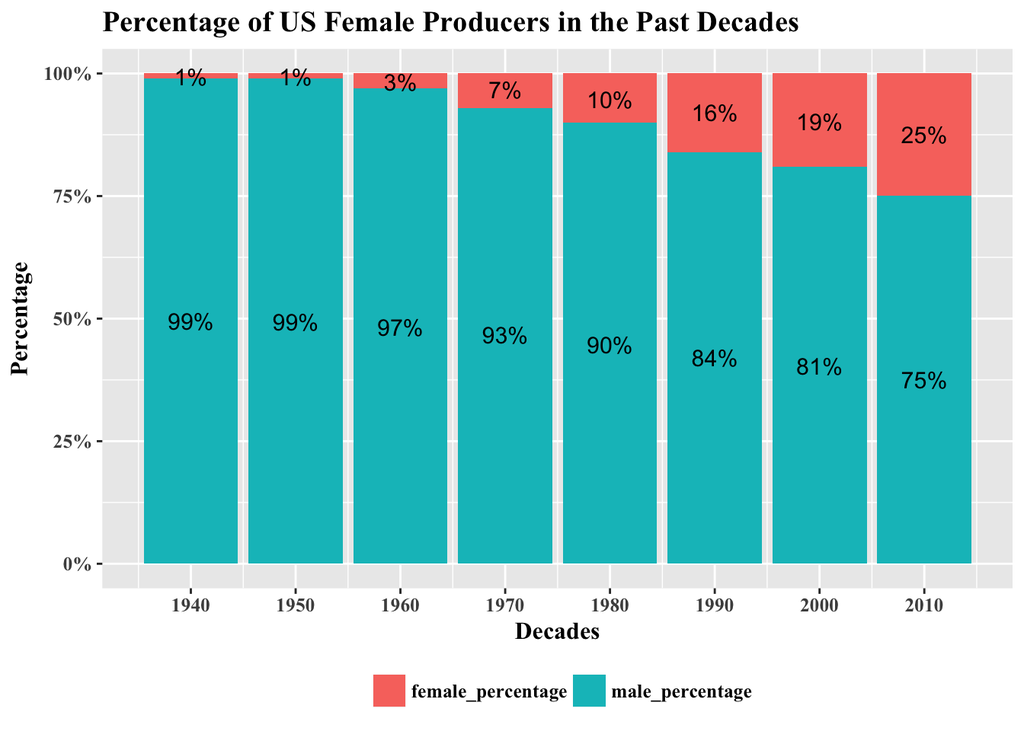

```r
library(mdsr)
library(RMySQL)
library(dplyr)
library(plyr)
load("big_data.rda")

# Producer
big_data3<- big_data2 %>%
  filter(role_id ==3, country == "USA" )%>%
  mutate(decade = 10 * floor(production_year / 10))%>%
  select(decade,gender,country) %>%
  group_by(decade, gender) %>%
  dplyr::summarize(N = n(), male = sum(ifelse(gender =="m",1,0)),
female = sum(ifelse(gender =="f",1,0)))
big_data4<- big_data3 %>%
  group_by(decade) %>%
  dplyr::summarize(N=n(),m = sum(male), f = sum(female))

d_percentage<- big_data4 %>%
  mutate(total = m+f,
  male_percentage = m/total,
  female_percentage = f/total) %>%
  select(male_percentage, female_percentage, decade, total) %>%
  tidyr::gather(key = "gender", value = "percentage", -decade, -total)

d_percentage <- ddply(d_percentage, .(decade),
                transform, pos = cumsum(percentage) - (0.5 * percentage))
p3 <- ggplot() + geom_bar(aes(y = round(percentage,digits =2), x = decade, fill = gender), data = d_percentage, stat="identity") +
geom_text(data=d_percentage, aes(x = decade, y = pos, label = paste0(round(percentage, digits= 2)*100,"%")), size=4) +
   labs(x = "Decades", y = "Percentage", title="Percentage of US Female Producers in the Past Decades")+
 scale_y_continuous(limits = c(0,1), breaks = c(0,0.25,0.50,0.75,1), labels = scales::percent)+
theme(text=element_text(family="Times New Roman", face="bold", size=12), legend.position="bottom", legend.direction="horizontal",
                  legend.title = element_blank()) +
                  scale_x_continuous(breaks=seq(1880,2010,10))
p3
```

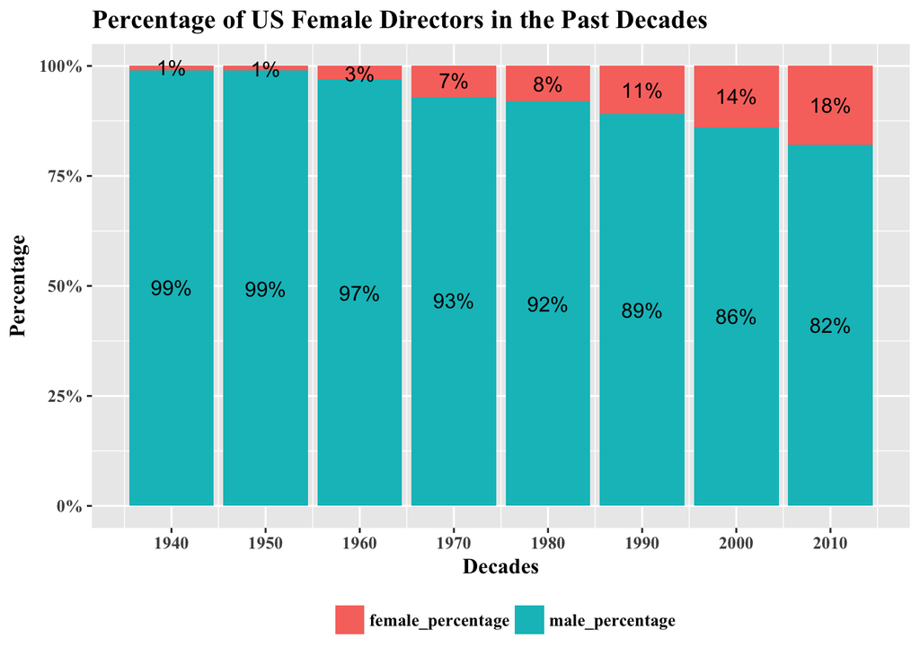

```r
#Director:
big_data5<- big_data2 %>%
  filter(role_id ==8, country == "USA") %>%
  mutate(decade = 10 * floor(production_year / 10))%>%
  select(decade,gender,country) %>%
  group_by(decade, gender,country) %>%
  dplyr::summarize(N = n(), male = sum(ifelse(gender =="m",1,0)),
female = sum(ifelse(gender =="f",1,0)))
big_data6<- big_data5 %>%
  group_by(decade) %>%
  dplyr::summarize(N=n(),m = sum(male), f = sum(female))

d_percentage2<- big_data6 %>%
  mutate(total = m+f,
  male_percentage = m/total,
  female_percentage = f/total) %>%
  select(male_percentage, female_percentage, decade, total) %>%
  tidyr::gather(key = "gender", value = "percentage", -decade, -total)

d_percentage2 <- ddply(d_percentage2, .(decade),
                transform, pos = cumsum(percentage) - (0.5 * percentage))
p4 <- ggplot() +
  geom_bar(aes(y = round(percentage,digits = 2), x = decade, fill = gender), data = d_percentage2, stat="identity") +
geom_text(data=d_percentage2, aes(x = decade, y = pos, label = paste0(round(percentage,digits = 2)*100,"%")), size=4)+
   labs(x = "Decades", y = "Percentage", title="Percentage of US Female Directors in the Past Decades")+
 scale_y_continuous(limits = c(0,1), breaks = c(0,0.25,0.50,0.75,1), labels = scales::percent)+
theme(text=element_text(family="Times New Roman", face="bold", size=12), legend.position="bottom", legend.direction="horizontal",
                  legend.title = element_blank()) +
                  scale_x_continuous(breaks=seq(1880,2010,10))
p4
```

## #MeToo, a Global Movement

We wanted to see if this increase in female filmmakers was only in the United States, or if a similar trend could be observed worldwide. Had other countries also been incorporated into the #MeToo movement, and what efforts had they made to increase representation of women creators? We compared five of the largest global film industries: the United States, India, Canada, Australia, and China.

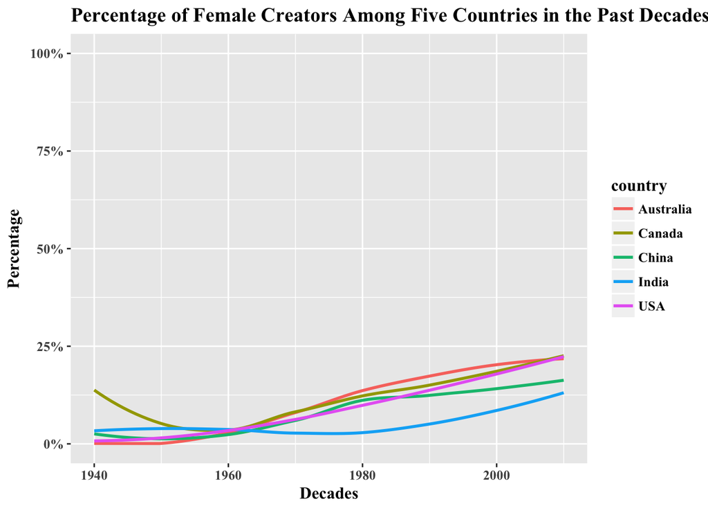

```r
# count bar graph if needed
big_data8<- big_data2 %>%
  mutate(decade = 10 * floor(production_year / 10))%>%
  select(decade,gender,country) %>%
  group_by(decade, gender,country) %>%
  dplyr::summarize(N = n(), male = sum(ifelse(gender =="m",1,0)),
female = sum(ifelse(gender =="f",1,0)))
big_data9<- big_data8 %>%
  group_by(decade,country) %>%
  dplyr::summarize(m = sum(male),
                   f = sum(female),
                   total = m+f,
                   female_percentage = f/total)
ggplot(big_data9,aes(x=decade, y=female_percentage))+
  geom_smooth(se=FALSE, aes(color = country))+
  scale_y_continuous(limits = c(0,1),labels = scales::percent, breaks = c(0,0.25,0.5,0.75,1))+
  labs(x = "Decades", y = "Percentage", title="Percentage of Female Creators Among Five Countries in the Past Decades")+
theme(text=element_text(family="Times New Roman", face="bold", size=12))
```

IMDb meticulously records Western films, but it does not have as detailed information on international films in languages besides English. Many movies released in India and China are not registered on IMDb, especially the lower-budget movies that women are more likely to direct or produce, so our data may be skewed. Even so, it is clear that the amount of female filmmakers has been increasing worldwide.

[figure not shown]

Krew Boylan, Rose Byrne, Jessica Carrera, Shannon Murphy and Gracie Otto, the founders of Dollhouse Pictures. Dollhouse Pictures is an Australian independent production company which prioritises female-driven storytelling.

Despite the global growth of women in film, the movement to end sexual assault is occurring almost exclusively in countries like Australia and Canada, who share relatively similar cultures and percentages of female filmmakers as the United States. In 2015, a group of female Directors Guild members, led by Gillian Armstrong [^3], pressured the Australian government’s public screen production fund to address the lack of female directors within Australian film. Australia [established several initiatives](https://www.if.com.au/screen-australia-reveals-gender-matters-three-tick-test/), including a “three ticks” policy, which ensured that 50% of all film projects the government backed by 2019 would have women in three of four creatives roles: producer, director, writer, or lead actor. This week, Australia announced that it was creating a sexual harassment code of practice that all film and TV companies must follow to be given government funding. A similar effort took place from 1974-1996 in Canada, where the Canadian government funded an studio which would exclusively make films by women filmmakers for and about women. It was a critical success, creating Oscar winning films about boundary-pushing social issues, but eventually ended due to lack of government funding. Australia and Canada used control of government [funds to support female filmmakers](http://time.com/5044854/hollywood-women-studio-d/), but Hollywood is almost exclusively driven by private companies. In order to take steps like Australia’s, Hollywood must promote stricter standards and financial incentives to increase its amount of female directors and producers. By doing so, women will be given the space they need to tell their stories, whether fictional or all too real.

Viewing date: December 14, 2017

[^1]: “Me Too” is a hashtag used on social media against sexual assault and harassment, in the wake of sexual misconduct allegations against film producer and executive Harvey Weinstein (Wikipedia)
[^2]: Increasing number of women working in film industries can be proved by the fellowing graphs
[^3]: Gillian Armstrong is an award-winning Australian feature film and documentary director who specializes in period drama. Her films often feature female perspectives and protagonists.[(Wikipedia)](https://en.wikipedia.org/wiki/Gillian_Armstrong)